# Practical Machine Learning

JoseCLee

19 September, 2014

## Synopsis

The objective of this assignment is to predict the class of the weight lifter base on the data from accelerometers on the belt, forearm, arm, and dumbell of 6 participants.

## Loading and preprocessing the data

Loading required libraries into R.

```r
library(ggplot2)
library(lattice)
library(caret)
library(rpart)
library(rpart.plot)
library(Hmisc)
library(corrgram)
library(e1071)
library(MASS)
library(randomForest)
set.seed(8586141)
```

Read data from csv file. Transform the empty space and *#DIV/0!* to NA when loading data into R.

```r
raw_training = read.csv(training_file, header=TRUE, na.strings = c(" ","","#DIV/0!"), );
private_testing = read.csv(testing_pfile, header=TRUE, na.strings = c(" ","","#DIV/0!"));
```

## Prepoccess

Combine training and private test data set for preprocessing  
1. Assign Temporary variables to align the number of variables in both data set  
2. Join 2 data set  
3. Take only sensor reading variables.

```r
private_testing$classe = NA
raw_training$problem_id = NA
combine = rbind(raw_training, private_testing)
combine = subset(combine, select = -c(X, user_name, raw_timestamp_part_1,raw_timestamp_part_2,
                                      cvtd_timestamp,cvtd_timestamp, new_window, num_window))
```

Taking out variables with large number of NA and transform all variables into numeric data type

```r
predictors = vector()
for(i in names(combine[,1:152]))
{
        combine[,i] = as.numeric(combine[,i])
        if (sum(is.na(combine[,i]))/length(combine[,i]) < 0.5)
        {
                predictors = rbind(predictors, i)
        }
}

combine = subset(combine, select = c(predictors, "classe", "problem_id"))
```

Splitting the data back to training and private testing set

```r
train_data = subset(combine, is.na(problem_id)==TRUE)
train_data = subset(train_data, select = -c(problem_id))
test_data = subset(combine, problem_id %in% 1:20)
rownames(test_data) = 1:20
test_data = subset(train_data, select = -c(classe))
```

Split training data to training and test set to train model

```r
split = createDataPartition(train_data$classe, list=FALSE, p = 0.7)
training = train_data[split,]
testing = train_data[-split,]
```

## Training Model

I have try on several models and found random forest has the best result although it took hours to train the model. (It took time even i removed the aggregation variables [total, avg, min, etc…] in another attempt.)

### Regression Tree

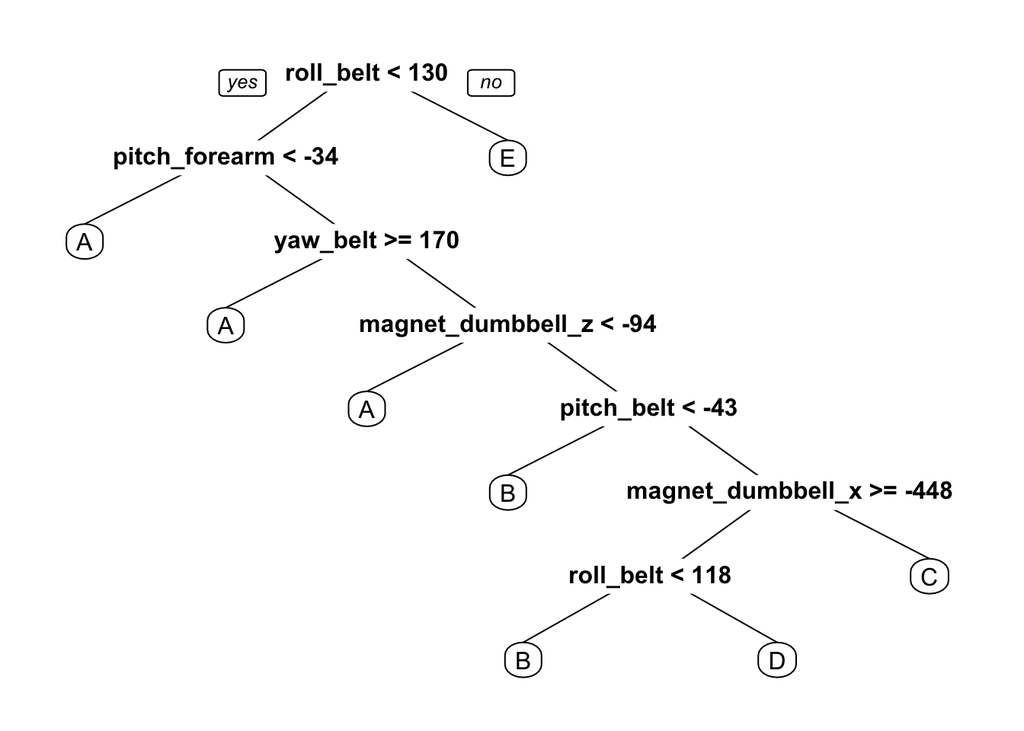

```r
fit.rpart = train(classe ~ ., data = training, method = "rpart")
prp(fit.rpart$finalModel)
```

```r
predict.rpart = predict(fit.rpart, newdata = testing)
confusionMatrix(predict.rpart, testing$classe)
```

```
## Confusion Matrix and Statistics
##
##           Reference
## Prediction    A    B    C    D    E
##          A 1005  181   21   51   16
##          B  161  642   44  148  256
##          C  343  267  814  496  281
##          D  134   49  147  269   48
##          E   31    0    0    0  481
##
## Overall Statistics
##
##                Accuracy : 0.546
##                  95% CI : (0.533, 0.558)
##     No Information Rate : 0.284
##     P-Value [Acc > NIR] : <2e-16
##
##                   Kappa : 0.431
##  Mcnemar's Test P-Value : <2e-16
##
## Statistics by Class:
##
##                      Class: A Class: B Class: C Class: D Class: E
## Sensitivity             0.600    0.564    0.793   0.2790   0.4445
## Specificity             0.936    0.872    0.715   0.9232   0.9935
## Pos Pred Value          0.789    0.513    0.370   0.4158   0.9395
## Neg Pred Value          0.855    0.893    0.942   0.8673   0.8881
## Prevalence              0.284    0.194    0.174   0.1638   0.1839
## Detection Rate          0.171    0.109    0.138   0.0457   0.0817
## Detection Prevalence    0.216    0.213    0.374   0.1099   0.0870
## Balanced Accuracy       0.768    0.718    0.754   0.6011   0.7190
```

**RPART** has 54% accuracy.

### Linear Discriminant Analysis

```r
fit.lda = train(classe ~ ., data = training, method = "lda")
predict.lda = predict(fit.lda, newdata = testing)
confusionMatrix(predict.lda, testing$classe)
```

```
## Confusion Matrix and Statistics
##
##           Reference
## Prediction    A    B    C    D    E
##          A 1390  170  123   57   40
##          B   27  717  101   41  178
##          C  102  154  662  108  115
##          D  150   48  127  714  113
##          E    5   50   13   44  636
##
## Overall Statistics
##
##                Accuracy : 0.7
##                  95% CI : (0.688, 0.712)
##     No Information Rate : 0.284
##     P-Value [Acc > NIR] : <2e-16
##
##                   Kappa : 0.62
##  Mcnemar's Test P-Value : <2e-16
##
## Statistics by Class:
##
##                      Class: A Class: B Class: C Class: D Class: E
## Sensitivity             0.830    0.629    0.645    0.741    0.588
## Specificity             0.907    0.927    0.901    0.911    0.977
## Pos Pred Value          0.781    0.674    0.580    0.620    0.850
## Neg Pred Value          0.931    0.912    0.923    0.947    0.913
## Prevalence              0.284    0.194    0.174    0.164    0.184
## Detection Rate          0.236    0.122    0.112    0.121    0.108
## Detection Prevalence    0.302    0.181    0.194    0.196    0.127
## Balanced Accuracy       0.869    0.778    0.773    0.826    0.782
```

**LDA** give pretty good score: 70% accuracy

### Random Forest

- Take long hours to train

```r
fit.rf = train(classe ~ ., data = training, method = "rf", importance=TRUE)
print(fit.rf$finalModel)
```

```
##
## Call:
##  randomForest(x = x, y = y, mtry = param$mtry, importance = TRUE)
##                Type of random forest: classification
##                      Number of trees: 500
## No. of variables tried at each split: 60
##
##         OOB estimate of  error rate: 0.69%
## Confusion matrix:
##      A    B    C    D    E class.error
## A 3901    3    1    0    1    0.001280
## B   21 2627   10    0    0    0.011663
## C    0    9 2377   10    0    0.007930
## D    0    2   21 2227    2    0.011101
## E    0    2    5    8 2510    0.005941
```

```r
predict.rf = predict(fit.rf, newdata = testing)
```

The accuracy from **RandomForest** is superb and i worry it could be over-fitting when predict against private data set.  
Let’s take a look on the and find which are importance variables.

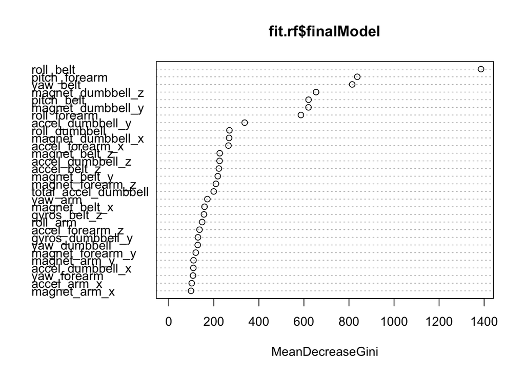

```r
varImpPlot(fit.rf$finalModel, type = 2)
```

I tested the out-of-sample error on the cross-validation set and the result was very encouraging:

```r
confusionMatrix(predict.rf, testing$classe)
```

```
## Confusion Matrix and Statistics
##
##           Reference
## Prediction    A    B    C    D    E
##          A 1673   10    0    0    0
##          B    1 1127    5    0    0
##          C    0    2 1015    9    0
##          D    0    0    6  954    4
##          E    0    0    0    1 1078
##
## Overall Statistics
##
##                Accuracy : 0.994
##                  95% CI : (0.991, 0.995)
##     No Information Rate : 0.284
##     P-Value [Acc > NIR] : <2e-16
##
##                   Kappa : 0.992
##  Mcnemar's Test P-Value : NA
##
## Statistics by Class:
##
##                      Class: A Class: B Class: C Class: D Class: E
## Sensitivity             0.999    0.989    0.989    0.990    0.996
## Specificity             0.998    0.999    0.998    0.998    1.000
## Pos Pred Value          0.994    0.995    0.989    0.990    0.999
## Neg Pred Value          1.000    0.997    0.998    0.998    0.999
## Prevalence              0.284    0.194    0.174    0.164    0.184
## Detection Rate          0.284    0.192    0.172    0.162    0.183
## Detection Prevalence    0.286    0.193    0.174    0.164    0.183
## Balanced Accuracy       0.999    0.994    0.994    0.994    0.998
```

## Summary & Submission

At the end of the analyst, predict the private testing set using *Random Forest* as it is the model with highest accuracy. The trade off is it taking longer time to train and less intepretability then others model like *rpart*.

By using the private test set and the code provided in **Coursera** platform, I predict it with the *fit.rf* model and turn it into 20 answer files.

```r
answers = predict(fit.rf, newdata = test_data)

if(!file.exists(file.path(getwd(), "submission")))
{
        dir.create(file.path(getwd(), "submission"))
}

pml_write_files = function(x,y){
        n = length(x)
        for(i in 1:n){
                filename = file.path(y, paste0("problem_id_",i,".txt"))
                write.table(x[i],file=filename,quote=FALSE,row.names=FALSE,col.names=FALSE)
        }
}

pml_write_files(answers, file.path(getwd(), "submission"))
```